# Transit Trips and Transportation Costs – County – Subgroups

Author

Tina Chelidze and Aaron R. Williams

Published

April 30, 2025

Abstract

This script calculates `share_transportation_cost` and `share_transit_commuter` using Center for Neighborhood Technology (CNT) and Census Bureau data.

**Tip**

Raw CNT data pulled from https://htaindex.cnt.org/download/.

1. Navigate to the data download page.
2. Select “Tracts”.
3. Download the data for all tracts.

To save time, we store data on Box in Metrics_2024_round/. See details under the Read Data section.*

## Setup

### Load Packages

```r
library(tidyverse)
library(tidycensus)
library(here)

source(here("functions", "testing", "evaluate_final_data.R"))

theme_set(theme_minimal())

options(scipen = 999)
```

### Read data

The data from CNT cannot be easily read directly into this program. Before running, please download the entirety of the folders listed below from the following [Box folder](https://urbanorg.app.box.com/folder/250262697073) into the repository folder. You may be required to unzip the folders but keep the raw files in their folders. `"mobility-from-poverty/06_neighborhoods/transportation/data/"`

- 2015_tract
- 2019_tract
- 2022_tract

```r
read_transportation_data <- function(year) {

  tractpath <- list.files(
    path = here("06_neighborhoods",
                "Transportation",
                "data",
                str_glue("{year}_tract")),
    pattern = "*.csv",
    full.names = TRUE
  )

  data <- map_dfr(tractpath, read_csv) |>
    mutate(year = year)

  return(data)

}

transportation_tracts <- map_dfr(
  .x = c(2015, 2019, 2022),
  .f = read_transportation_data
)
```

## Clean Transportation Data

Create correct FIPS columns.

```r
transportation_tracts <- transportation_tracts |>
  rename(GEOID = tract) |>
  mutate(
    state = substr(GEOID, start = 2, stop = 3),
    county = substr(GEOID, start = 4, stop = 6),
    tract = substr(GEOID, start = 7, stop = 12)
  )
```

```r
transportation_tracts <- transportation_tracts |>
  mutate(GEOID = paste0(state, county, tract))
```

```r
transportation_tracts <- transportation_tracts |>
  select(
    year, GEOID, state, county, tract, blkgrps, population, households,
    share_transit_commuter = pct_transit_commuters_80ami,
    share_transportation_cost = t_80ami
  )
```

We drop tracts without households. Some of these tracts have population but the population must be in group quarters or on reservations. For example, one tract from the North Slope Borough in Alaska has people but no households.

```r
transportation_tracts <- transportation_tracts |>
  filter(households > 0)
```

We transform transportation cost from an unlabeled percentage to a proportion.

```r
transportation_tracts <- transportation_tracts |>
  mutate(
    share_transit_commuter = share_transit_commuter / 100,
    share_transportation_cost = share_transportation_cost / 100
  )
```

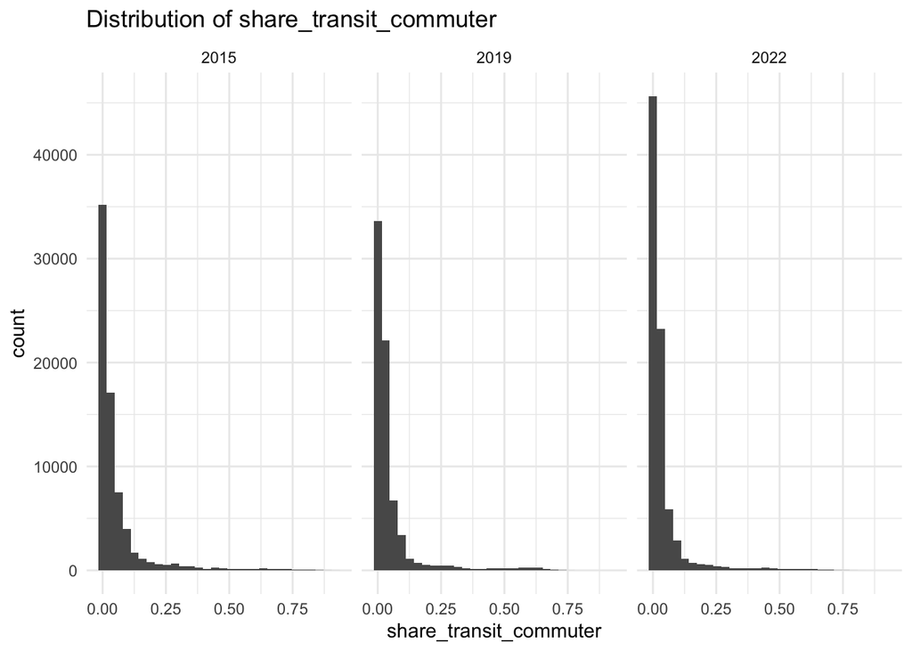

```r
transportation_tracts |>
  ggplot(aes(share_transit_commuter)) +
  geom_histogram() +
  facet_wrap(~ year) +
  labs(title = "Distribution of share_transit_commuter")
```

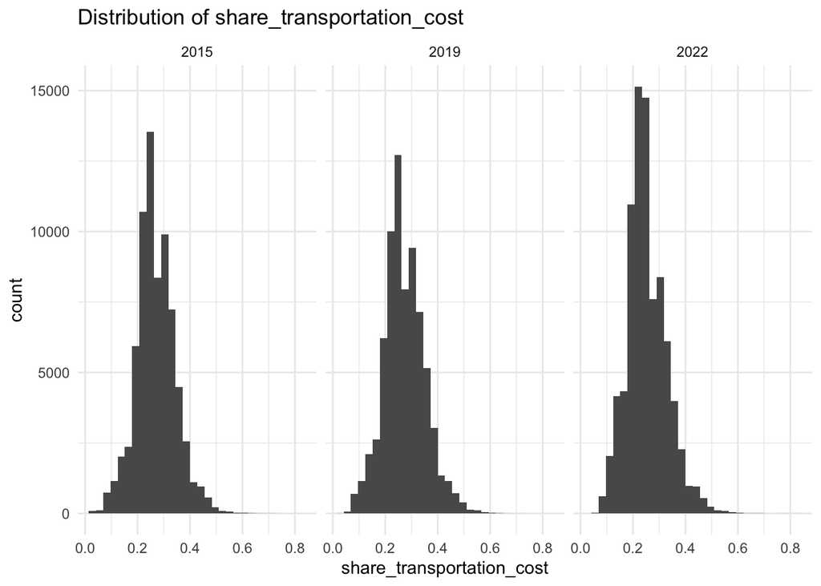

```r
transportation_tracts |>
  ggplot(aes(share_transportation_cost)) +
  geom_histogram() +
  facet_wrap(~ year) +
  labs(title = "Distribution of share_transportation_cost")
```

## Clean Census Data

We need to pull Census Bureau data to calculate data quality and to calculate subgroups. We start by pulling `B25001_001`, which is the estimate and margin of error for the number of households in the tract.

```r
my_states <- fips_codes |>
  filter(!state %in% c("PR", "UM", "VI", "GU", "AS", "MP")) |>
  pull(state) |>
  unique()
```

```r
acs_sample_size <- bind_rows(
  `2015` = map_dfr(
    .x = my_states,
    .f = ~ get_acs(
      geography = "tract",
      state = .x,
      variables = c("B00002_001", "B25001_001"),
      year = 2015,
      survey = "acs5",
      output = "wide"
    )
  ),
  `2019` = map_dfr(
    .x = my_states,
    .f = ~ get_acs(
      geography = "tract",
      state = .x,
      variables = c("B25001_001"),
      year = 2019,
      survey = "acs5",
      output = "wide"
    )
  ),
  `2022` = map_dfr(
    .x = my_states,
    .f = ~ get_acs(
      geography = "tract",
      state = .x,
      variables = c("B25001_001"),
      year = 2022,
      survey = "acs5",
      output = "wide"
    )
  ),
  .id = "year"
) |>
  rename(
    sample_size = B00002_001E,
    households_est = B25001_001E,
    households_moe = B25001_001M
  ) |>
  mutate(
    year = as.numeric(year),
    state = str_sub(GEOID, start = 1, end = 2),
    county = str_sub(GEOID, start = 3, end = 5)
  )
```

Turn a 90% MOE into a standard error.

```r
acs_sample_size <- acs_sample_size |>
  mutate(
    households_se = households_moe / qnorm(0.95)
  )
```

`sample_size` is only pulled for exploratory uses.

```r
acs_sample_size <- acs_sample_size |>
  select(-sample_size)
```

After this, there shouldn’t be any missing values.

```r
stopifnot(
  all(map_dbl(acs_sample_size, ~sum(is.na(.x))) == 0)
)
```

We need to pull counts of different races and ethnicities at the census tract level to identify tracts for the subgroup analysis. To do this, we pull detailed information and roll up the categories. The following table shows the race/ethnicity categories and the combination of ACS variables into our new variables.

| Variable. | Depth | Description | New Variable |
| --- | --- | --- | --- |
| `B03002_001` | 1 | Estimate!!Total | `total_population` |
| `B03002_002` | 2 | Estimate!!Total!!Not Hispanic or Latino | `NA` |
| `B03002_003` | 3 | Estimate!!Total!!Not Hispanic or Latino!!White alone | `whitenh` |
| `B03002_004` | 3 | Estimate!!Total!!Not Hispanic or Latino!!Black or African American alone | `poc` |
| `B03002_005` | 3 | Estimate!!Total!!Not Hispanic or Latino!!American Indian and Alaska Native alone | `poc` |
| `B03002_006` | 3 | Estimate!!Total!!Not Hispanic or Latino!!Asian alone | `poc` |
| `B03002_007` | 3 | Estimate!!Total!!Not Hispanic or Latino!!Native Hawaiian and Other Pacific Islander alone | `poc` |
| `B03002_008` | 3 | Estimate!!Total!!Not Hispanic or Latino!!Some other race alone | `poc` |
| `B03002_009` | 3 | Estimate!!Total!!Not Hispanic or Latino!!Two or more races | `poc` |
| `B03002_010` | 4 | Estimate!!Total!!Not Hispanic or Latino!!Two or more races!!Two races including Some other race | `NA` |
| `B03002_011` | 4 | Estimate!!Total!!Not Hispanic or Latino!!Two or more races!!Two races excluding Some other race, and three or more races | `NA` |
| `B03002_012` | 2 | Estimate!!Total!!Hispanic or Latino | `poc` |
| `B03002_013` | 3 | Estimate!!Total!!Hispanic or Latino!!White alone | `NA` |
| `B03002_014` | 3 | Estimate!!Total!!Hispanic or Latino!!Black or African American alone | `NA` |
| `B03002_015` | 3 | Estimate!!Total!!Hispanic or Latino!!American Indian and Alaska Native alone | `NA` |
| `B03002_016` | 3 | Estimate!!Total!!Hispanic or Latino!!Asian alone | `NA` |
| `B03002_017` | 3 | Estimate!!Total!!Hispanic or Latino!!Native Hawaiian and Other Pacific Islander alone | `NA` |
| `B03002_018` | 3 | Estimate!!Total!!Hispanic or Latino!!Some other race alone | `NA` |
| `B03002_019` | 3 | Estimate!!Total!!Hispanic or Latino!!Two or more races | `NA` |
| `B03002_020` | 4 | Estimate!!Total!!Hispanic or Latino!!Two or more races!!Two races including Some other race | `NA` |
| `B03002_021` | 4 | Estimate!!Total!!Hispanic or Latino!!Two or more races!!Two races excluding Some other race, and three or more races | `NA` |

```r
acs_tract_pop15 <- map_dfr(
  .x = my_states,
  .f = ~ get_acs(
    geography = "tract",
    state = .x,
    table = "B03002",
    year = 2015,
    survey = "acs5",
    output = "wide"
  )
)

acs_tract_pop19 <- map_dfr(
  .x = my_states,
  .f = ~ get_acs(
    geography = "tract",
    state = .x,
    table = "B03002",
    year = 2019,
    survey = "acs5",
    output = "wide"
  )
)

acs_tract_pop22 <- map_dfr(
  .x = my_states,
  .f = ~ get_acs(
    geography = "tract",
    state = .x,
    table = "B03002",
    year = 2022,
    survey = "acs5",
    output = "wide"
  )
)

acs_tracts <- bind_rows(
  `2015` = acs_tract_pop15,
  `2019` = acs_tract_pop19,
  `2022` = acs_tract_pop22,
  .id = "year"
) |>
  mutate(year = as.numeric(year))

acs_tracts <- acs_tracts |>
  mutate(
    state = substr(GEOID, start = 1, stop = 2),
    county = substr(GEOID, start = 3, stop = 5),
    tract = substr(GEOID, start = 6, stop = 11)
  )

rm(acs_tract_pop15, acs_tract_pop19, acs_tract_pop22)
```

We join the data quality information to the main demographic information.

```r
acs_tracts <- full_join(
  acs_tracts,
  acs_sample_size,
  by = c("year", "state", "county", "GEOID"),
  relationship = "one-to-one"
)
```

Rename columns for clarity and calculate counts of people by different races and ethnicities.

```r
acs_tracts <- acs_tracts |>
  rename(
    total_population = B03002_001E,
    non_hispanic = B03002_002E,
    white_nh = B03002_003E,
    hispanic = B03002_012E
  ) |>
  mutate(
    poc_non_hispanic =
      B03002_004E +
      B03002_005E +
      B03002_006E +
      B03002_007E +
      B03002_008E +
      B03002_009E
  ) |>
  mutate(poc = poc_non_hispanic + hispanic)

stopifnot(
  acs_tracts |>
    filter(total_population != (white_nh + poc_non_hispanic + hispanic)) |>
    nrow() == 0
)

stopifnot(
  acs_tracts |>
    filter(total_population != (white_nh + poc)) |>
    nrow() == 0
)
```

Keep only vars we want.

```r
acs_tracts <- acs_tracts |>
  select(
    year, GEOID, state, county, tract, total_population, white_nh, poc,
    households_est, households_se
  )
```

## Merge Data

We join the ACS demographic information to the transportation information.

```r
combined_tracts <- left_join(
  transportation_tracts,
  acs_tracts,
  by = c("year", "GEOID", "state", "county", "tract")
)
```

No tracts with transportation data are missing demographic data. There are demographic tracts without transportation information but this is expected because of empty tracts and tracts without households.

```r
anti_join(
  transportation_tracts,
  acs_tracts,
  by = c("year", "GEOID", "state", "county", "tract")
)
```

```
# A tibble: 0 × 10
# ℹ 10 variables: year <dbl>, GEOID <chr>, state <chr>, county <chr>,
#   tract <chr>, blkgrps <dbl>, population <dbl>, households <dbl>,
#   share_transit_commuter <dbl>, share_transportation_cost <dbl>
```

```r
anti_join(
  acs_tracts,
  transportation_tracts,
  by = c("year", "GEOID", "state", "county", "tract")
) |>
  filter(total_population > 0)
```

```
# A tibble: 620 × 10
    year GEOID state county tract total_population white_nh   poc households_est
   <dbl> <chr> <chr> <chr>  <chr>            <dbl>    <dbl> <dbl>          <dbl>
 1  2015 0109… 01    097    0036…              634      395   239              0
 2  2015 0218… 02    185    0003…             3056     2569   487              0
 3  2015 0402… 04    027    9800…              622       44   578              0
 4  2015 0401… 04    013    1134…              255      137   118              0
 5  2015 0401… 04    013    0610…             3373     1472  1901              0
 6  2015 0401… 04    019    0041…             4531     1563  2968              0
 7  2015 0401… 04    013    9804…               10        6     4              0
 8  2015 0607… 06    073    0055…              199      107    92              0
 9  2015 0606… 06    065    9810…             6742     1128  5614              0
10  2015 0603… 06    037    5746…             2142      838  1304              0
# ℹ 610 more rows
# ℹ 1 more variable: households_se <dbl>
```

## Calculate race category

For each tract, ID the race category by calculating the proportion White, Non-Hispanic and the proportion of every other race and ethnicity.

```r
combined_tracts <- combined_tracts |>
  mutate(
    prop_white_nh = white_nh / total_population,
    prop_poc = poc / total_population
  )

stopifnot(
  combined_tracts |>
    filter(prop_white_nh + prop_poc != 1) |>
    nrow() == 0
)
```

Assign race-category for each tract. These assignments should align with the debt metric.

```r
combined_tracts <- combined_tracts |>
  mutate(
    subgroup = case_when(
      total_population == 0 ~ "No population",
      prop_white_nh >= 0.6 ~ "White neighborhoods",
      prop_poc >= 0.6 ~ "Neighborhoods of color",
      prop_white_nh >= 0.4 | prop_poc >= 0.4 ~ "Mixed neighborhoods",
      prop_white_nh < 0.4 & prop_poc < 0.4 ~ as.character(NA)
    )
  )

combined_tracts |>
  count(subgroup)
```

```
# A tibble: 3 × 2
  subgroup                    n
  <chr>                   <int>
1 Mixed neighborhoods     33069
2 Neighborhoods of color  58633
3 White neighborhoods    136129
```

## Calculate metrics

We average census tracts to the county-race/ethnicity group with weights for the number of households in each tract. [This document](https://www2.census.gov/programs-surveys/acs/tech_docs/accuracy/2018_ACS_Accuracy_Document_Worked_Examples.pdf?) outlines the strategy for approximating the standard error.

```r
transportation_county_all <- combined_tracts |>
  filter(subgroup != "No population") |>
  group_by(year, state, county) |>
  summarize(
    n = n(),
    share_transit_commuter = weighted.mean(x = share_transit_commuter, w = households),
    share_transportation_cost = weighted.mean(x = share_transportation_cost, w = households),
    households_est = sum(households_est),
    households_se = sqrt(sum(households_se ^ 2)),
    households = sum(households)
  ) |>
  mutate(
    subgroup_type = "all",
    subgroup = "All"
  ) |>
  ungroup()

transportation_county_subgroup <- combined_tracts |>
  filter(subgroup != "No population") |>
  group_by(year, state, county, subgroup) |>
  summarize(
    n = n(),
    share_transit_commuter = weighted.mean(x = share_transit_commuter, w = households),
    share_transportation_cost = weighted.mean(x = share_transportation_cost, w = households),
    households_est = sum(households_est),
    households_se = sqrt(sum(households_se ^ 2)),
    households = sum(households)
  ) |>
  mutate(
    subgroup_type = "race-ethnicity"
  ) |>
  ungroup()

transportation_county <- bind_rows(
  transportation_county_all,
  transportation_county_subgroup
)
```

Some county-race/ethnicity groups are missing. This is because some race/ethnicity groups don’t exist in each county. We load the target geography file, join our statistics to the target geography file, and then add zeros for household sizes and `4` for standard errors. `4` isn’t scientific and just seems reasonable looking at other standard errors.

```r
target_statistics <- read_csv(here("geographic-crosswalks", "data", "county-populations.csv")) |>
  filter(year %in% c(2015, 2019, 2022)) |>
  select(year, state, county) |>
  expand_grid(subgroup = c("All", "Neighborhoods of color", "White neighborhoods", "Mixed neighborhoods")) |>
  mutate(subgroup_type = if_else(subgroup == "All", "all", "race-ethnicity"))

transportation_county <- full_join(
  target_statistics,
  transportation_county,
  by = c("year", "state", "county", "subgroup_type", "subgroup")
)

transportation_county <- transportation_county |>
  mutate(
    households = if_else(is.na(households), 0, households),
    households_est = if_else(is.na(households_est), 0, households_est),
    households_se = if_else(is.na(households_se), 4, households_se)
  )
```

## Transit Trips Quality Control Checks

### Missing Data

```r
transportation_county |>
  filter(is.na(share_transit_commuter)) |>
  count(subgroup)
```

```
# A tibble: 4 × 2
  subgroup                   n
  <chr>                  <int>
1 All                        1
2 Mixed neighborhoods     5687
3 Neighborhoods of color  6617
4 White neighborhoods      539
```

### Distribution

Use stopifnot to check if all values in `transportation_county` are non-negative.

```r
stopifnot(min(transportation_county$share_transit_commuter, na.rm = TRUE) >= 0)
```

Create a histogram.

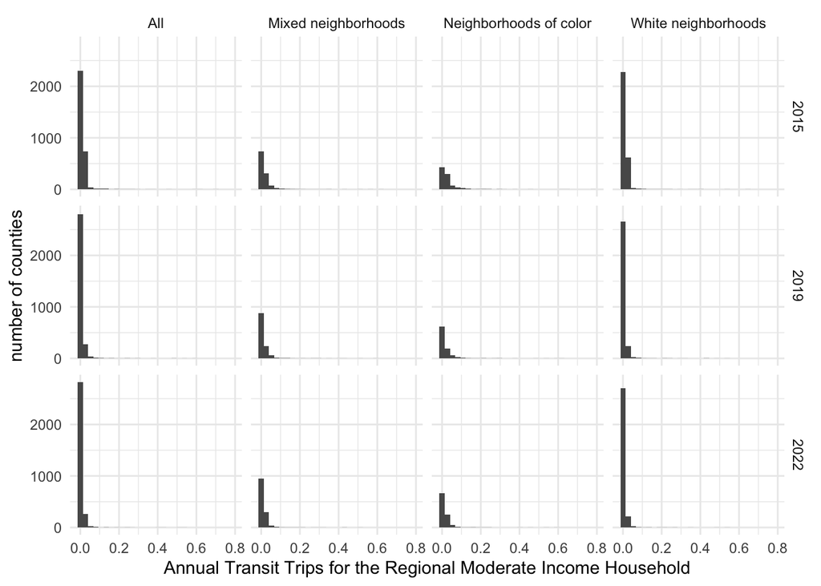

```r
ggplot(transportation_county, aes(x = share_transit_commuter)) +
  geom_histogram() +
  facet_grid(year ~ subgroup) +
  labs(
    x = "Annual Transit Trips for the Regional Moderate Income Household",
    y = "number of counties"
  )
```

Makes sense for most counties to fall in really low transit trip numbers since most of the US has no public infrastructure that can be used for daily transport.

Look at summary stats

```r
summary(transportation_county$share_transit_commuter)
```

```
   Min. 1st Qu.  Median    Mean 3rd Qu.    Max.    NA's
  0.000   0.000   0.003   0.011   0.010   0.781   12844
```

Examine extreme values

```r
transportation_county |>
  group_by(year) |>
  slice_max(n = 10, order_by = share_transit_commuter) |>
  select(year, state, county, subgroup, share_transit_commuter) |>
  print(n = Inf)
```

```
# A tibble: 30 × 5
# Groups:   year [3]
    year state county subgroup               share_transit_commuter
   <dbl> <chr> <chr>  <chr>                                   <dbl>
 1  2015 36    061    Neighborhoods of color                  0.781
 2  2015 36    061    All                                     0.687
 3  2015 36    061    White neighborhoods                     0.644
 4  2015 36    047    Neighborhoods of color                  0.633
 5  2015 36    005    Neighborhoods of color                  0.630
 6  2015 36    061    Mixed neighborhoods                     0.628
 7  2015 36    005    All                                     0.607
 8  2015 36    047    All                                     0.600
 9  2015 36    047    Mixed neighborhoods                     0.578
10  2015 36    047    White neighborhoods                     0.550
11  2019 36    061    Neighborhoods of color                  0.612
```

[output cut: 19 more lines]

### Change

We look at the change from 2015 to 2019. Transit trips changes a lot, which may cause us to question the data quality.

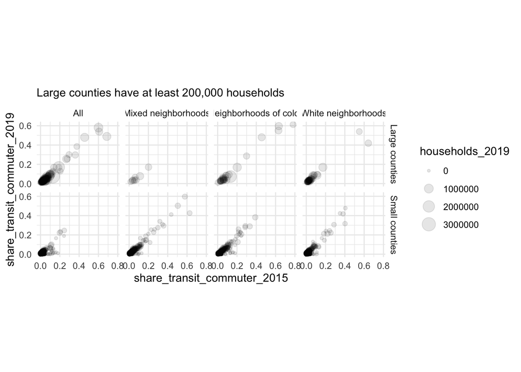

```r
transportation_county |>
  filter(year %in% c(2015, 2019)) |>
  select(state, county, year, subgroup, households, share_transit_commuter) |>
  pivot_wider(
    names_from = year,
    values_from = c(households, share_transit_commuter)
  ) |>
  mutate(size = if_else(households_2019 > 200000, "Large counties", "Small counties")) |>
  ggplot(aes(share_transit_commuter_2015, share_transit_commuter_2019, size = households_2019)) +
  geom_point(alpha = 0.1) +
  facet_grid(size ~ subgroup) +
  coord_equal() +
  labs(subtitle = "Large counties have at least 200,000 households")
```

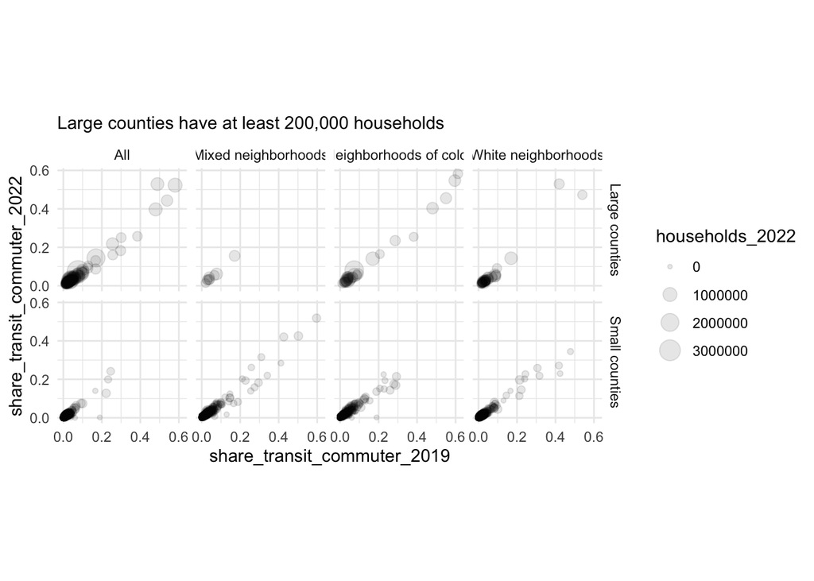

```r
transportation_county |>
  filter(year %in% c(2019, 2022)) |>
  select(state, county, year, subgroup, households, share_transit_commuter) |>
  pivot_wider(
    names_from = year,
    values_from = c(households, share_transit_commuter)
  ) |>
  mutate(size = if_else(households_2022 > 200000, "Large counties", "Small counties")) |>
  filter(!is.na(households_2022)) |>
  ggplot(aes(share_transit_commuter_2019, share_transit_commuter_2022, size = households_2022)) +
  geom_point(alpha = 0.1) +
  facet_grid(size ~ subgroup) +
  coord_equal() +
  labs(subtitle = "Large counties have at least 200,000 households")
```

```r
transportation_county |>
  group_by(state, county, subgroup) |>
  mutate(change_share_transit_commuter = share_transit_commuter - lag(share_transit_commuter)) |>
  ungroup() |>
  filter(year %in% c(2019, 2022)) |>
  slice_max(order_by = abs(change_share_transit_commuter), n = 10) |>
  select(year, state, county, subgroup, change_share_transit_commuter)
```

```
# A tibble: 10 × 5
    year state county subgroup               change_share_transit_commuter
   <dbl> <chr> <chr>  <chr>                                          <dbl>
 1  2019 36    061    White neighborhoods                           -0.224
 2  2019 36    061    Mixed neighborhoods                           -0.201
 3  2019 36    061    All                                           -0.198
 4  2022 36    005    White neighborhoods                           -0.194
 5  2022 02    016    All                                           -0.188
 6  2022 02    016    Neighborhoods of color                        -0.188
 7  2019 02    013    All                                           -0.17
 8  2019 02    013    Neighborhoods of color                        -0.17
 9  2019 36    061    Neighborhoods of color                        -0.169
10  2022 36    081    White neighborhoods                           -0.146
```

## Cost Quality Control Checks

### Missing Data

```r
transportation_county |>
  filter(is.na(share_transportation_cost))
```

```
# A tibble: 12,844 × 11
    year state county subgroup        subgroup_type     n share_transit_commuter
   <dbl> <chr> <chr>  <chr>           <chr>         <int>                  <dbl>
 1  2015 01    001    Neighborhoods … race-ethnici…    NA                     NA
 2  2015 01    003    Mixed neighbor… race-ethnici…    NA                     NA
 3  2015 01    005    White neighbor… race-ethnici…    NA                     NA
 4  2015 01    007    Neighborhoods … race-ethnici…    NA                     NA
 5  2015 01    009    Neighborhoods … race-ethnici…    NA                     NA
 6  2015 01    009    Mixed neighbor… race-ethnici…    NA                     NA
 7  2015 01    011    White neighbor… race-ethnici…    NA                     NA
 8  2015 01    019    Neighborhoods … race-ethnici…    NA                     NA
 9  2015 01    019    Mixed neighbor… race-ethnici…    NA                     NA
10  2015 01    021    Neighborhoods … race-ethnici…    NA                     NA
# ℹ 12,834 more rows
# ℹ 4 more variables: share_transportation_cost <dbl>, households_est <dbl>,
#   households_se <dbl>, households <dbl>
```

### Distribution

Use stopifnot to check if all values in `transportation_county` are non-negative.

```r
stopifnot(min(transportation_county$share_transportation_cost, na.rm = TRUE) >= 0)
```

Create a histogram.

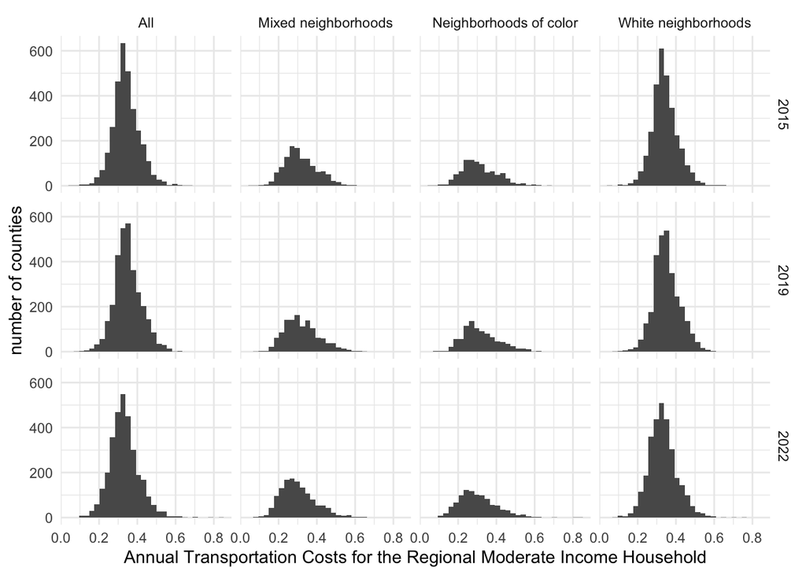

```r
ggplot(transportation_county, aes(x = share_transportation_cost)) +
  geom_histogram() +
  facet_grid(year ~ subgroup) +
  labs(
    x = "Annual Transportation Costs for the Regional Moderate Income Household",
    y = "number of counties"
  )
```

Look at summary stats

```r
summary(transportation_county$share_transportation_cost)
```

```
   Min. 1st Qu.  Median    Mean 3rd Qu.    Max.    NA's
  0.046   0.284   0.330   0.333   0.380   0.830   12844
```

Examine extreme values

```r
transportation_county |>
  group_by(year) |>
  slice_max(n = 10, order_by = share_transportation_cost) |>
  select(year, state, county, subgroup, share_transportation_cost) |>
  print(n = Inf)
```

```
# A tibble: 34 × 5
# Groups:   year [3]
    year state county subgroup               share_transportation_cost
   <dbl> <chr> <chr>  <chr>                                      <dbl>
 1  2015 01    119    All                                        0.672
 2  2015 01    119    Neighborhoods of color                     0.672
 3  2015 21    147    All                                        0.646
 4  2015 21    147    White neighborhoods                        0.646
 5  2015 22    107    White neighborhoods                        0.64
 6  2015 01    063    All                                        0.631
 7  2015 01    063    Neighborhoods of color                     0.631
 8  2015 21    189    All                                        0.617
 9  2015 21    189    White neighborhoods                        0.617
10  2015 13    061    All                                        0.61
11  2015 13    061    Neighborhoods of color                     0.61
```

[output cut: 23 more lines]

### Change

We look at the change from 2015 to 2019. Transportation costs are very stable during this time period.

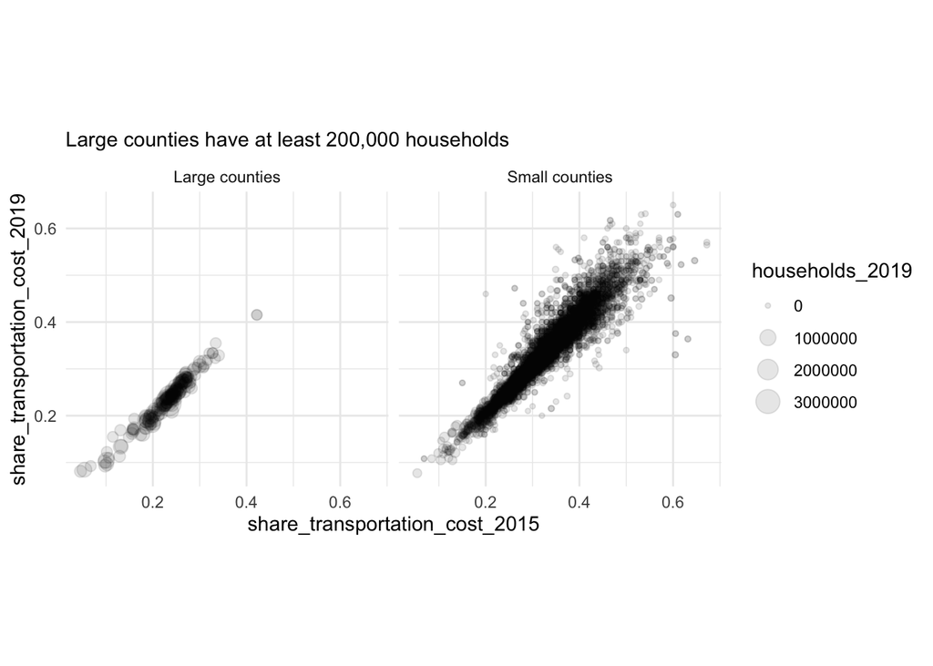

```r
transportation_county |>
  filter(year %in% c(2015, 2019)) |>
  select(state, county, year, subgroup, households, share_transportation_cost) |>
  pivot_wider(
    names_from = year,
    values_from = c(households, share_transportation_cost)
  ) |>
  mutate(size = if_else(households_2019 > 200000, "Large counties", "Small counties")) |>
  ggplot(aes(share_transportation_cost_2015, share_transportation_cost_2019, size = households_2019)) +
  geom_point(alpha = 0.1) +
  facet_wrap(~ size) +
  coord_equal() +
  labs(subtitle = "Large counties have at least 200,000 households")
```

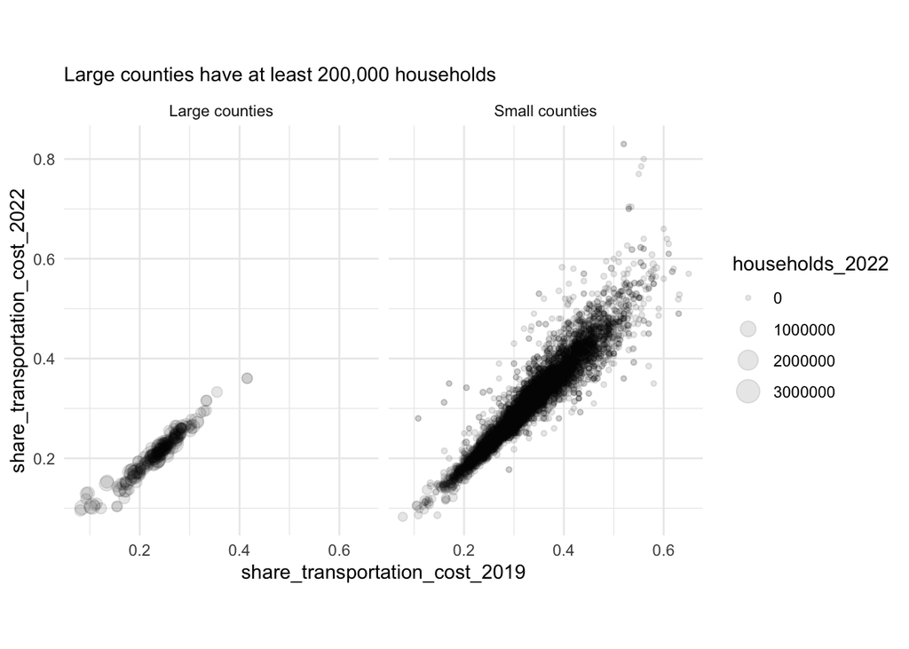

```r
transportation_county |>
  filter(year %in% c(2019, 2022)) |>
  select(state, county, year, subgroup, households, share_transportation_cost) |>
  pivot_wider(
    names_from = year,
    values_from = c(households, share_transportation_cost)
  ) |>
  mutate(size = if_else(households_2022 > 200000, "Large counties", "Small counties")) |>
  filter(!is.na(households_2022)) |>
  ggplot(aes(share_transportation_cost_2019, share_transportation_cost_2022, size = households_2022)) +
  geom_point(alpha = 0.1) +
  facet_wrap(~ size) +
  coord_equal() +
  labs(subtitle = "Large counties have at least 200,000 households")
```

```r
transportation_county |>
  group_by(state, county, subgroup) |>
  mutate(change_share_transportation_cost = share_transportation_cost - lag(share_transportation_cost)) |>
  ungroup() |>
  filter(year %in% c(2019, 2022)) |>
  slice_max(order_by = abs(change_share_transportation_cost), n = 10)  |>
  select(year, state, county, subgroup, share_transportation_cost)
```

```
# A tibble: 10 × 5
    year state county subgroup               share_transportation_cost
   <dbl> <chr> <chr>  <chr>                                      <dbl>
 1  2022 28    055    All                                        0.83
 2  2022 28    055    Neighborhoods of color                     0.83
 3  2019 28    051    All                                        0.330
 4  2019 28    051    Neighborhoods of color                     0.330
 5  2019 01    063    All                                        0.364
 6  2019 01    063    Neighborhoods of color                     0.364
 7  2019 02    282    All                                        0.46
 8  2022 46    071    Neighborhoods of color                     0.8
 9  2022 46    071    All                                        0.785
10  2022 48    271    All                                        0.35
```

## Data Quality Marker

We calculate data quality using the coefficient of variation for the number of households and median household income. We use the “worse” data quality from these two tests.

Elsewhere, we use 0.2 and 0.4 as cutoffs for the coefficient of variation. These metrics contain extra uncertainty from other variables and modelings, so we use 0.08 and 0.15 as cutoffs.

```r
transportation_county <- transportation_county |>
  mutate(households_cv = households_se / households_est)

transportation_county <- transportation_county |>
  mutate(
    share_transit_commuter_quality = case_when(
      households_cv < 0.08 ~ 1,
      households_cv < 0.15 ~ 2,
      TRUE ~ 3
    ),
    share_transportation_cost_quality  = case_when(
      households_cv < 0.08 ~ 1,
      households_cv < 0.15 ~ 2,
      TRUE ~ 3
    )
  ) |>
  mutate(
    share_transit_commuter_quality = if_else(is.na(share_transit_commuter), NA, share_transit_commuter_quality),
    share_transportation_cost_quality = if_else(is.na(share_transportation_cost), NA, share_transportation_cost_quality)
  )
```

Next, we load and calculate the coefficient of variation for median household income at the county level.

```r
med_hh_income_cv <- bind_rows(
  `2015` = get_acs(
    geography = "county",
    variables = "B19013_001",
    year = 2015,
    survey = "acs5",
    output = "wide"
  ),
  `2019` = get_acs(
    geography = "county",
    variables = "B19013_001",
    year = 2019,
    survey = "acs5",
    output = "wide"
  ),
  `2022` = get_acs(
    geography = "county",
    variables = "B19013_001",
    year = 2022,
    survey = "acs5",
    output = "wide"
  ),
  .id = "year"
) |>
  rename(
    med_hh_income = B19013_001E,
    med_hh_income_moe = B19013_001M,
  ) |>
  mutate(
    year = as.numeric(year),
    state = str_sub(GEOID, start = 1, end = 2),
    county = str_sub(GEOID, start = 3, end = 5)
  )

med_hh_income_cv <- med_hh_income_cv |>
  mutate(med_hh_income_se = med_hh_income_moe / qnorm(0.95)) |>
  # calculate the coefficient of variation
  mutate(med_hh_income_cv = med_hh_income_se / med_hh_income) |>
  mutate(med_hh_income_cv = ifelse(is.na(med_hh_income_cv), 0.5, med_hh_income_cv)) |>
  mutate(
    share_transit_commuter_quality = case_when(
      med_hh_income_cv < 0.1 ~ 1,
      med_hh_income_cv < 0.3 ~ 2,
      TRUE ~ 3
    ),
    share_transportation_cost_quality  = case_when(
      med_hh_income_cv < 0.1 ~ 1,
      med_hh_income_cv < 0.3 ~ 2,
      TRUE ~ 3
    )
  ) |>
  select(
    year, state, county,
    share_transit_commuter_quality_county = share_transit_commuter_quality,
    share_transportation_cost_quality_county = share_transportation_cost_quality
  )
```

We use the worse quality between county median household income and aggregated census tracts coefficient of variation.

```r
transportation_county <- left_join(
  transportation_county,
  med_hh_income_cv,
  by = c("year", "state", "county")
)

transportation_county <- transportation_county |>
  mutate(
    share_transit_commuter_quality =
      pmax(share_transit_commuter_quality, share_transit_commuter_quality_county),
    share_transportation_cost_quality =
      pmax(share_transportation_cost_quality, share_transportation_cost_quality_county)
  )
```

Examine the data quality flags.

```r
count(transportation_county, year, share_transit_commuter_quality)
```

```
# A tibble: 12 × 3
    year share_transit_commuter_quality     n
   <dbl>                          <dbl> <int>
 1  2015                              1  7900
 2  2015                              2   273
 3  2015                              3    23
 4  2015                             NA  4372
 5  2019                              1  7846
 6  2019                              2   378
 7  2019                              3    25
 8  2019                             NA  4319
 9  2022                              1  7560
10  2022                              2   810
11  2022                              3    53
12  2022                             NA  4153
```

```r
count(transportation_county, year, share_transportation_cost_quality)
```

```
# A tibble: 12 × 3
    year share_transportation_cost_quality     n
   <dbl>                             <dbl> <int>
 1  2015                                 1  7900
 2  2015                                 2   273
 3  2015                                 3    23
 4  2015                                NA  4372
 5  2019                                 1  7846
 6  2019                                 2   378
 7  2019                                 3    25
 8  2019                                NA  4319
 9  2022                                 1  7560
10  2022                                 2   810
11  2022                                 3    53
12  2022                                NA  4153
```

Confirm no metrics are missing quality flags.

```r
stopifnot(
  transportation_county |>
    filter(
      (!is.na(share_transit_commuter) & is.na(share_transit_commuter_quality)) |
        (!is.na(share_transportation_cost) & is.na(share_transportation_cost_quality))
    ) |>
    nrow() == 0
)

stopifnot(
  transportation_county |>
    filter(
      (is.na(share_transit_commuter) & !is.na(share_transit_commuter_quality)) |
        (is.na(share_transportation_cost) & !is.na(share_transportation_cost_quality))
    ) |>
    nrow() == 0
)
```

## Export final subgroup files

Keep variables of interest and order them appropriately.

```r
final_data <- transportation_county |>
  select(year, state, county, subgroup_type, subgroup, share_transit_commuter, share_transit_commuter_quality, share_transportation_cost, share_transportation_cost_quality)
```

Run the evaluation function.

```r
evaluate_final_data(
  exp_form_path = here("10a_final-evaluation", "evaluation_form_transportation_county-subgroup.csv"),
  data = final_data,
  geography = "county",
  confidence_intervals = FALSE,
  subgroups = TRUE
)
```

```
[1] "This data passes all tests!"
```

```r
final_data |>
  arrange(year, state, county) |>
  write_csv(
    here("06_neighborhoods",
         "Transportation",
         "final",
         "transportation_subgroup_county.csv")
  )
```

## Export final overall file

```r
final_overall_data <- transportation_county |>
  filter(subgroup == "All") |>
  select(year, state, county, share_transit_commuter, share_transit_commuter_quality, share_transportation_cost, share_transportation_cost_quality)
```

Run the evaluation function.

```r
evaluate_final_data(
  exp_form_path = here("10a_final-evaluation", "evaluation_form_transportation_county.csv"),
  data = final_overall_data,
  geography = "county",
  confidence_intervals = FALSE
)
```

```
[1] "This data passes all tests!"
```

Write the final data.

```r
final_overall_data |>
  write_csv(
    here("06_neighborhoods",
         "Transportation",
         "final",
         "transportation_all_county.csv")
  )
```